# DHS comparison

I copied this over from a .R file on Nov 17, 2016 and simplified some of the code. Since we’re only interested in DHS by tenax and DCSE by twister, I’ve deleted quite a bit of code.

# Importing the data

```r
#input <- read_csv("DHS Comparison updated 4-7-2017.csv") #Nicole added back two compounds she previously removed as contaminants.  They're not actually contaminants.
input <- read_csv("DHS Comparison updated 6-4-2017.csv") #Nicole updated to remove some compounds that are plasticizers and others that are below a modified LOQ
input2 <- input[1:12, ]
#glimpse(input2)
input2[is.na(input2)] <- 0  #NA's represent 0's
#Read in annotated library for later extraction of LogKOW and vapor pressure
#library <- read_csv("annotated library mar 13 2017.csv")
#library <- read_csv("annotated library apr 6 2017.csv")
```

create treatment variables

```r
vars <- colsplit(input2$Treatment, "\\.", c("Method", "Treatment", "Rep"))
vars
```

| Method | Treatment | Rep |
| --- | --- | --- |
| DHS | Cont | 1 |
| DHS | Cont | 2 |
| DHS | Cont | 3 |
| DHS | MeJA | 1 |
| DHS | MeJA | 2 |
| DHS | MeJA | 3 |
| DCSE | Cont | 1 |
| DCSE | Cont | 2 |
| DCSE | Cont | 3 |
| DCSE | MeJA | 1 |

[output cut: 2 more lines]

```r
len <- dim(input2)[2]
data <- cbind(vars$Method, vars$Treatment, input2[ , 2:len])
colnames(data)[1:2] <- c("Method","Treatment")
head(data)
```

|  | Method | Treatment | Acetaldehyde | Ethyl alcohol | Methyl vinyl ketone | 2-Butanone | Furan, 2-methyl- | 2-Butanol | Isobutyronitrile | Furan, tetrahydro- | Isovaleraldehyde | Benzene | 1-Butanol | Pentanal | 2-Propanone, 1-hydroxy- | 1-Pentene, 2,4,4-trimethyl- | Ethoxy ethanol<2-> | Butanenitrile, 2-methyl- | Butanenitrile, 3-methyl- | 1-Butanol, 3-methyl- | Propanoic acid | 2-Propenoic acid | Pyrrole | Toluene | Propyl aldoxime, 2-methyl-, anti- | 2-Butenal, 3-methyl- | Cyclopentanone | Octane | 3-Penten-2-one, 4-methyl- | … |
| --- | --- | --- | --- | --- | --- | --- | --- | --- | --- | --- | --- | --- | --- | --- | --- | --- | --- | --- | --- | --- | --- | --- | --- | --- | --- | --- | --- | --- | --- | --- |
| 1 | DHS | Cont | 0.08272 | 0.13304 | 0.14070 | 0.13288 | 0.00000 | 0.02575 | 0.00000 | 0.00967 | 0.10192 | 0.48715 | 0.06054769 | 0.06759 | 0.43314 | 0.00000 | 0.03292 | 0.02756 | 0.00000 | 0.000 | 0.36723 | 0.10857 | 0.00000 | 2.37702 | 0.00000 | 0.01229 | 0.04855986 | 0.07404 | 0.02834 | … |
| 2 | DHS | Cont | 0.06777 | 0.18536 | 0.06432 | 0.10890 | 0.00187 | 0.00000 | 0.00000 | 0.00986 | 0.09679 | 0.28333 | 0.00000000 | 0.05023 | 0.34842 | 0.03447 | 0.02116 | 0.01609 | 0.00000 | 0.000 | 0.23066 | 0.03516 | 0.00000 | 2.65426 | 0.00000 | 0.01768 | 0.03967000 | 0.07829 | 0.03019 | … |
| 3 | DHS | Cont | 0.04215 | 0.09986 | 0.05053 | 0.07250 | 0.00000 | 0.02807 | 0.00000 | 0.00478 | 0.00000 | 0.21907 | 0.02488000 | 0.03697 | 0.03141 | 0.00000 | 0.00000 | 0.00000 | 0.00000 | 0.000 | 0.18501 | 0.01617 | 0.00000 | 0.43414 | 0.00000 | 0.00658 | 0.03866000 | 0.04556 | 0.00000 | … |
| 4 | DHS | MeJA | 0.10590 | 0.14876 | 0.46809 | 0.28109 | 0.07560 | 0.15723 | 0.20702 | 0.01640 | 0.22271 | 0.21440 | 0.05618000 | 0.04513 | 0.41251 | 0.03384 | 0.01665 | 7.69683 | 15.54295 | 0.115 | 0.25048 | 0.08276 | 0.03025 | 1.55559 | 0.08157 | 0.05153 | 0.03605000 | 0.00000 | 0.02977 | … |
| 5 | DHS | MeJA | 0.07531 | 0.14666 | 0.76689 | 0.30366 | 0.12898 | 0.11559 | 0.11766 | 0.01592 | 0.21722 | 0.26237 | 0.00000000 | 0.05124 | 0.43773 | 0.02590 | 0.01111 | 4.50618 | 9.03261 | 0.069 | 0.15393 | 0.12435 | 0.02271 | 2.15717 | 0.12607 | 0.05766 | 0.04099000 | 0.00000 | 0.04383 | … |
| 6 | DHS | MeJA | 0.08036 | 0.12262 | 0.05275 | 0.07991 | 0.00140 | 0.01322 | 0.00000 | 0.00897 | 0.03085 | 0.26815 | 0.01475000 | 0.03891 | 0.54197 | 0.00000 | 0.00000 | 0.03030 | 0.04392 | 0.000 | 0.10713 | 0.00486 | 0.00568 | 0.60193 | 0.00000 | 0.00701 | 0.03105000 | 0.00000 | 0.00000 | … |

```r
#glimpse(data)
```

find any compounds that are constants

```r
counts <- head(summarise_each(data, funs(n_distinct)))
rm <- which(counts <= 1)
if(length(rm) != 0){
data <- subset(data, select = -rm)}
#glimpse(data)
```

## With only DHS Tenax vs. DCSE Twister

```r
data %>% group_by(Method) %>% summarise_all(funs(mean)) -> compare.data
```

```
argument is not numeric or logical: returning NAargument is not numeric or logical: returning NA
```

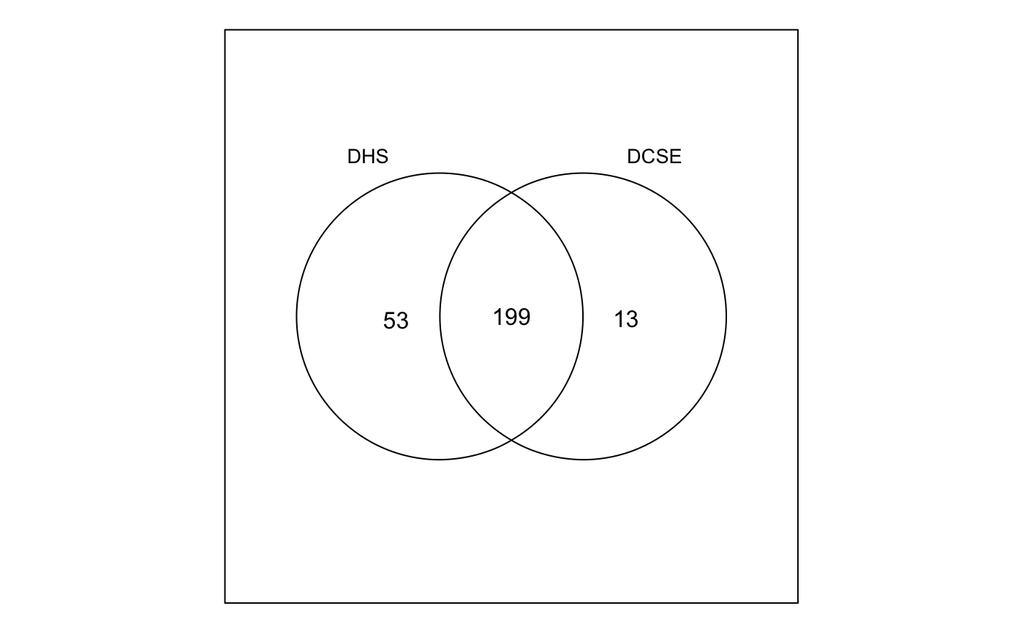

```r
compare.data[ , -(1:2)] %>% t() %>% as.data.frame() -> compare.data
colnames(compare.data) <- c("DHS", "DCSE")
compare.data$Compound <- rownames(compare.data)
rownames(compare.data) <- NULL
##Venn Diagram
method.logical <- compare.data
method.logical$DHS[method.logical$DHS != 0] <- 1
method.logical$DCSE[method.logical$DCSE !=0] <- 1
venn(method.logical[ , 1:2], cexil = 1, cexsn = .85)
```

```r
#Extract Unique Compounds
select(compare.data, Compound, everything()) %>% filter(DHS == 0 & DCSE != 0 | DHS !=0 & DCSE ==0) -> method_unique_compounds
#left_join(method_unique_compounds, library, by = c("Compound" = "IA_Name")) %>% select(Compound, DHS, DCSE, Log_P, Vapor_Pressure, Vapor_Pressure_At) -> method_unique_compounds
method_unique_compounds
```

| Compound | DHS | DCSE |
| --- | --- | --- |
| Benzophenone | 0.03979833 | 0.000000000 |
| Hexane, 3-methyl- | 0.01608833 | 0.000000000 |
| Heptane | 0.05925500 | 0.000000000 |
| 2-Propenoic acid, 2-methyl-, methyl ester | 0.17629333 | 0.000000000 |
| 2-Pentenal, (E)- | 0.02205833 | 0.000000000 |
| Pentanol | 0.04278167 | 0.000000000 |
| 2,4-Pentanedione | 0.00000000 | 0.007343333 |
| 134 | 0.04915167 | 0.000000000 |
| Heptane, 3-methylene- | 0.01740333 | 0.000000000 |
| 2-Hexanone | 0.03718500 | 0.000000000 |

[output cut: 56 more lines]

```r
colSums(method.logical[ , 1:2])
```

```
 DHS DCSE
 252  212
```

## By treatment

```r
data %>% group_by(Treatment) %>% summarise_all(funs(mean)) -> treatment.data
```

```
argument is not numeric or logical: returning NAargument is not numeric or logical: returning NA
```

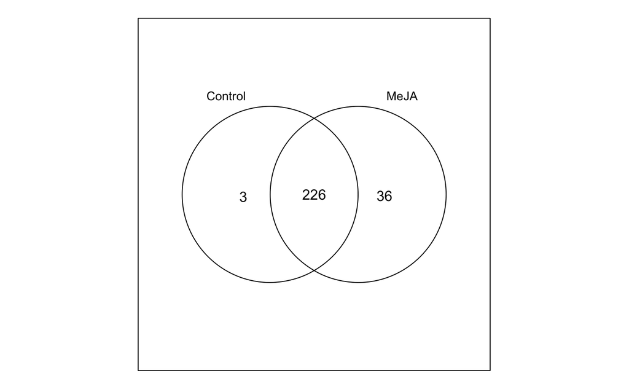

```r
treatment.data[ , -(1:2)] %>% t() %>% as.data.frame() -> treatment.data
colnames(treatment.data) <- c("Control", "MeJA")
treatment.data$Compound <- rownames(treatment.data)
rownames(treatment.data) <- NULL
##Venn Diagram
treatment.logical <- treatment.data
treatment.logical$Control[treatment.logical$Control != 0] <- 1
treatment.logical$MeJA[treatment.logical$MeJA !=0] <- 1
venn(treatment.logical[ , 1:2], cexil = 1, cexsn = .85)
```

```r
#Extract Unique Compounds
select(treatment.data, Compound, everything()) %>% filter(Control == 0 & MeJA != 0 | Control !=0 & MeJA ==0) -> treatment_unique_compounds
#left_join(treatment_unique_compounds, library, by = c("Compound" = "IA_Name")) %>% select(Compound, Control, MeJA, Log_P, Vapor_Pressure, Vapor_Pressure_At) -> treatment_unique_compounds
treatment_unique_compounds
```

| Compound | Control | MeJA |
| --- | --- | --- |
| Isobutyronitrile | 0.000000000 | 0.09240000 |
| Butanenitrile, 3-methyl- | 0.000000000 | 7.58720000 |
| 1-Butanol, 3-methyl- | 0.000000000 | 0.10934667 |
| Propyl aldoxime, 2-methyl-, anti- | 0.000000000 | 0.15388833 |
| 15 | 0.000000000 | 0.04400667 |
| Butyl aldoxime, 3-methyl-, syn- | 0.000000000 | 2.46855833 |
| Butyl aldoxime, 2-methyl-, syn- | 0.000000000 | 1.61605000 |
| Butyl aldoxime, 2-methyl-, anti- | 0.000000000 | 0.29528333 |
| Hexenol | 0.000000000 | 0.03250333 |
| 1,5-Heptadiene, 2,6-dimethyl- | 0.000000000 | 0.03707000 |

[output cut: 29 more lines]

```r
colSums(treatment.logical[ , 1:2])
```

```
Control    MeJA
    229     262
```

229 compounds in Control, `262` found in MeJA treated plants. 3 compounds are unique to Control plants and 36 compounds are unique to MeJA treated plants.

## By treatment AND method

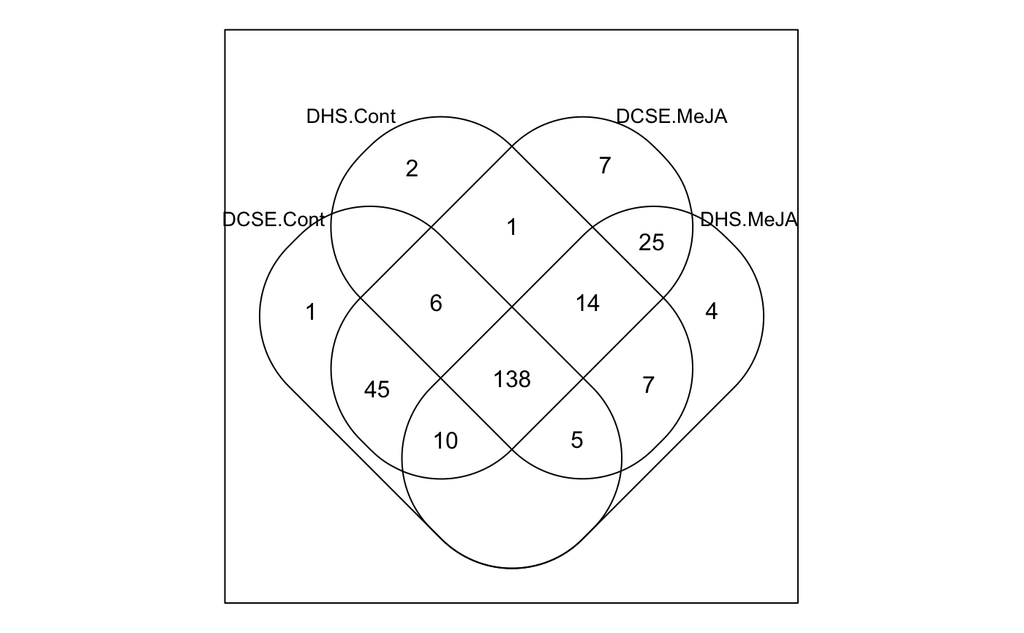

```r
data %>% group_by(Treatment, Method) %>% summarise_all(funs(mean)) -> combo.data
combo.data[ , -(1:2)] %>% t() %>% as.data.frame() -> combo.data1
colnames(combo.data1) <- paste(combo.data$Method, combo.data$Treatment, sep = ".")
combo.data1$Compound <- rownames(combo.data1)
rownames(combo.data1) <- NULL
##Venn Diagram
combo.logical <- combo.data1
combo.logical$DHS.Cont[combo.logical$DHS.Cont != 0] <- 1
combo.logical$DCSE.Cont[combo.logical$DCSE.Cont != 0] <- 1
combo.logical$DHS.MeJA[combo.logical$DHS.MeJA != 0] <- 1
combo.logical$DCSE.MeJA[combo.logical$DCSE.MeJA != 0] <- 1
venn(combo.logical[ , 1:4], cexil = 1, cexsn = .85)
```

```r
colSums(combo.logical[ , 1:4])
```

```
DCSE.Cont  DHS.Cont DCSE.MeJA  DHS.MeJA
      205       173       246       203
```

```r
#unique to MeJA/DCSE combo
combo.logical %>% filter(DCSE.MeJA == 1, DCSE.Cont == 0, DHS.Cont == 0, DHS.MeJA == 0)
```

| DCSE.Cont | DHS.Cont | DCSE.MeJA | DHS.MeJA | Compound |
| --- | --- | --- | --- | --- |
| 0 | 0 | 1 | 0 | Benzophenone |
| 0 | 0 | 1 | 0 | Hexane, 3-methyl- |
| 0 | 0 | 1 | 0 | 2-Pentenal, (E)- |
| 0 | 0 | 1 | 0 | 134 |
| 0 | 0 | 1 | 0 | Heptane, 3-methylene- |
| 0 | 0 | 1 | 0 | 10 |
| 0 | 0 | 1 | 0 | 3,7-Octadiene-2,6-diol, 2,6-dimethyl- |

```r
#unique to MeJA/DHS combo
combo.logical %>% filter(DCSE.MeJA == 0, DCSE.Cont == 0, DHS.Cont == 0, DHS.MeJA == 1)
```

| DCSE.Cont | DHS.Cont | DCSE.MeJA | DHS.MeJA | Compound |
| --- | --- | --- | --- | --- |
| 0 | 0 | 0 | 1 | Ocimene |
| 0 | 0 | 0 | 1 | Cymen-8-ol |
| 0 | 0 | 0 | 1 | Geranyl formate |
| 0 | 0 | 0 | 1 | Murrolol (=tau-muurolol) |

## Write to a file

```r
#xlsx package broken currently
#write.xlsx(method_unique_compounds, "unique compounds DHS comparison.xlsx",
#           sheetName = "By Method", row.names = FALSE)
#write.xlsx(treatment_unique_compounds, "unique compounds DHS comparison.xlsx",
#           sheetName = "By Treatment", row.names = FALSE, append = TRUE)
```

# PCA

I conduct a PCA and plot PC1 vs PC2

```r
data.scaled <- scale(data[3:length(data)])
all.pca <- prcomp(data.scaled, scale. = FALSE, center = FALSE)
summary(all.pca)
```

```
Importance of components%s:
                           PC1    PC2    PC3     PC4     PC5     PC6     PC7     PC8     PC9    PC10    PC11
Standard deviation     10.3639 7.1958 5.5835 4.74723 4.02523 3.29047 2.87947 2.61186 2.06772 1.91342 1.42121
Proportion of Variance  0.4053 0.1954 0.1176 0.08504 0.06114 0.04086 0.03129 0.02574 0.01613 0.01382 0.00762
Cumulative Proportion   0.4053 0.6007 0.7184 0.80340 0.86454 0.90540 0.93669 0.96243 0.97856 0.99238 1.00000
                            PC12
Standard deviation     2.312e-15
Proportion of Variance 0.000e+00
Cumulative Proportion  1.000e+00
```

```r
#4 PCs to capture ~80% of variance
#screeplot(all.pca,type="l")
```

80% of variation captured in ~4 PCs

## PCA Plot

```r
##my ggplot2 theme
multivar.theme <- theme_bw(base_size = 7, base_family = "Helvetica")+  #this changes the default text size and font
  theme(axis.title = element_text(size = 7),                      #this sets a different font size for the axis labels
        panel.border = element_rect(size = .5, color = "black"),   #change size= here to change border size
        panel.grid.major = element_blank(),                     #these two lines make the grid lines go away
        panel.grid.minor = element_blank(),
        legend.text = element_text(size = 7, family = "Arial"),                  #legend font size
        legend.background = element_rect(color = "black", size = 0.25))
        #legend.key.size = unit(.68, "lines"),
        #legend.spacing = unit(.4, "lines"))         #changes horizontal spacing
```

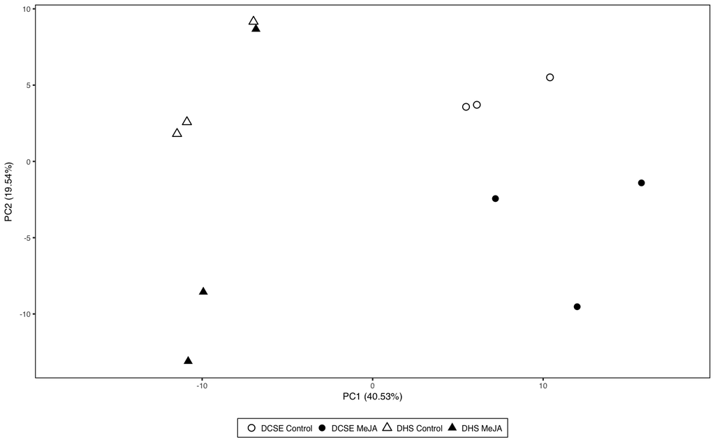

```r
Method <- data$Method
Treatment <- data$Treatment
levels(Treatment) <- c("Control", "MeJA")
Combined <- as.factor(paste(Method, Treatment))
#black and white with open vs. closed triangles and circles
#shape.labels = c("DCSE", "DHS")
#col.labels = c("Control", "MeJA")
#cols <- c("Control" = "NA", "MeJA" = "black")
#ggplot(as.data.frame(all.pca$x), aes(PC1, PC2)) +
#  geom_point(aes(shape = Combined), size = I(2)) +
#  xlim(-18, 18) +
#  multivar.theme +
#  #scale_fill_manual(name = "Method and Treatment",
#                    labels = Combined,
#                    values = cols) +
#  scale_shape_manual(name = NULL,
#                     values = c(16, 17, 1, 2),
#                     labels = levels(Combined)) +
#  #guides(fill = guide_legend(override.aes = list(color = cols))) +
#  #theme(legend.position = "right", legend.box = "vertical") +
#  ylab(paste0("PC2 (",round(summary(all.pca)$importance[2,2]*100, 2), "%)")) +
#  xlab(paste0("PC1 (",round(summary(all.pca)$importance[2,1]*100, 2), "%)"))
#ggsave("Comparison PCA bw.png", width = 5, height = 3.33, units = "in")
#ok, for some reason Robbat wants shape to represent method and filled/unfilled to represent treatment
ggplot(as.data.frame(all.pca$x), aes(PC1, PC2)) +
  geom_point(aes(shape = Combined), size = I(2)) +
  xlim(-18, 18) +
  multivar.theme +
  scale_shape_manual(name = NULL,
                     values = c(1, 16, 2, 17),
                     labels = levels(Combined),
                     guide = guide_legend(nrow = 1)) +
  theme(legend.position = "bottom") +
  theme(legend.key.size = unit(.68, "lines")) +
  theme(legend.margin = margin(t = 2, b = 2, r = 4, l = 1)) +
  ylab(paste0("PC2 (",round(summary(all.pca)$importance[2,2]*100, 2), "%)")) +
  xlab(paste0("PC1 (",round(summary(all.pca)$importance[2,1]*100, 2), "%)"))
ggsave("Comparison PCA bw4.png", height = 3.5, width = 3.33, units = "in")
```

# Correlations

```r
write.xlsx(PC1.corr.sig, "PCA compounds DHS comparison.xlsx",
           sheetName = "PC1", col.names = TRUE, row.names = FALSE)
```

[output not shown]

An alternative method might be to use FDR corrected t-tests since it is very clear that PC1 separates the methods and PC2 separates the treatments

```r
important.PC1.data <- select(data, one_of(as.character(PC1.corr.sig$.Variables)))
sig.tests.PC1 <- vector(mode = "numeric", length = length(important.PC1.data))
for(i in 1:length(important.PC1.data)){
  test <- t.test(important.PC1.data[[i]] ~ data$Method)
  sig.tests.PC1[i] <- test$p.value
}
important.PC2.data <- select(data, one_of(as.character(PC2.corr.sig$.Variables)))
sig.tests.PC2 <- vector(mode = "numeric", length = length(important.PC2.data))
for(i in 1:length(important.PC2.data)){
  test <- t.test(important.PC2.data[[i]] ~ data$Treatment)
  sig.tests.PC2[i] <- test$p.value
}
```

# ANOVA (really just t-tests?)

Using the PCA scores, test if there is significant difference between methods, treatments, interaction?? (2 way ANOVA)

```r
df <- data.frame(treatment = Treatment, method = Method, PC1 = all.pca$x[ , 1], PC2 = all.pca$x[ , 2])
df
```

| treatment | method | PC1 | PC2 |
| --- | --- | --- | --- |
| Control | DHS | -10.893359 | 2.583311 |
| Control | DHS | -11.471945 | 1.810617 |
| Control | DHS | -6.988395 | 9.164966 |
| MeJA | DHS | -9.931801 | -8.558099 |
| MeJA | DHS | -10.820352 | -13.100121 |
| MeJA | DHS | -6.845734 | 8.671866 |
| Control | DCSE | 10.400673 | 5.509840 |
| Control | DCSE | 6.111559 | 3.710692 |
| Control | DCSE | 5.478060 | 3.577279 |
| MeJA | DCSE | 15.765413 | -1.408172 |

[output cut: 2 more lines]

```r
#interaction was non-significant
anova(lm(PC1 ~ treatment+method, data = df))
```

```
Analysis of Variance Table

Response: PC1
          Df  Sum Sq Mean Sq  F value    Pr(>F)
treatment  1   18.07   18.07   1.9771    0.1933
method     1 1081.16 1081.16 118.2727 1.772e-06 ***
Residuals  9   82.27    9.14
---
Signif. codes:  0 ‘***’ 0.001 ‘**’ 0.01 ‘*’ 0.05 ‘.’ 0.1 ‘ ’ 1
```

```r
t.test(PC1 ~ method, data = df)
```

```
    Welch Two Sample t-test

data:  PC1 by method
t = 10.38, df = 7.488, p-value = 1.04e-05
alternative hypothesis: true difference in means is not equal to 0
95 percent confidence interval:
 14.71572 23.25200
sample estimates:
mean in group DCSE  mean in group DHS
          9.491931          -9.491931
```

```r
anova(lm(PC2 ~ treatment+method, data = df))
```

```
Analysis of Variance Table

Response: PC2
          Df Sum Sq Mean Sq F value  Pr(>F)
treatment  1 231.56 231.559  6.1674 0.03479 *
method     1   0.11   0.109  0.0029 0.95816
Residuals  9 337.91  37.545
---
Signif. codes:  0 ‘***’ 0.001 ‘**’ 0.01 ‘*’ 0.05 ‘.’ 0.1 ‘ ’ 1
```

```r
t.test(PC2 ~ treatment, data = df)
```

```
    Welch Two Sample t-test

data:  PC2 by treatment
t = 2.6173, df = 6.1432, p-value = 0.03887
alternative hypothesis: true difference in means is not equal to 0
95 percent confidence interval:
  0.6182687 16.9528680
sample estimates:
mean in group Control    mean in group MeJA
             4.392784             -4.392784
```